# Observed2M_Model

Ben Weinstein

June 6, 2016

```
## [1] "Run Completed at 2016-07-22 21:40:57"
```

```r
#Load in data from Observed2m_Generate.Rmd
load("Observed.RData")
#load("ObservedModel.RData")
newModel<-T
```

```r
#source functions
source("Bayesian/BayesFunctions.R")
```

# View Raw Data

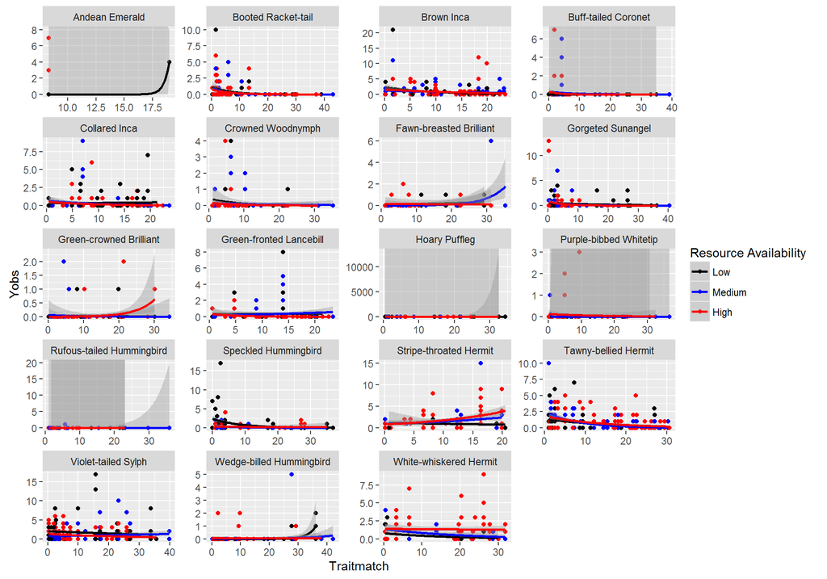

```r
ggplot(indat,aes(x=Traitmatch,y=Yobs,col=as.factor(R))) + facet_wrap(~Hummingbird,ncol=4,scales="free") + geom_point() + geom_smooth(method = "glm",method.args=list(family="poisson")) + scale_color_manual("Resource Availability",values=c("black",'blue','red'))
```

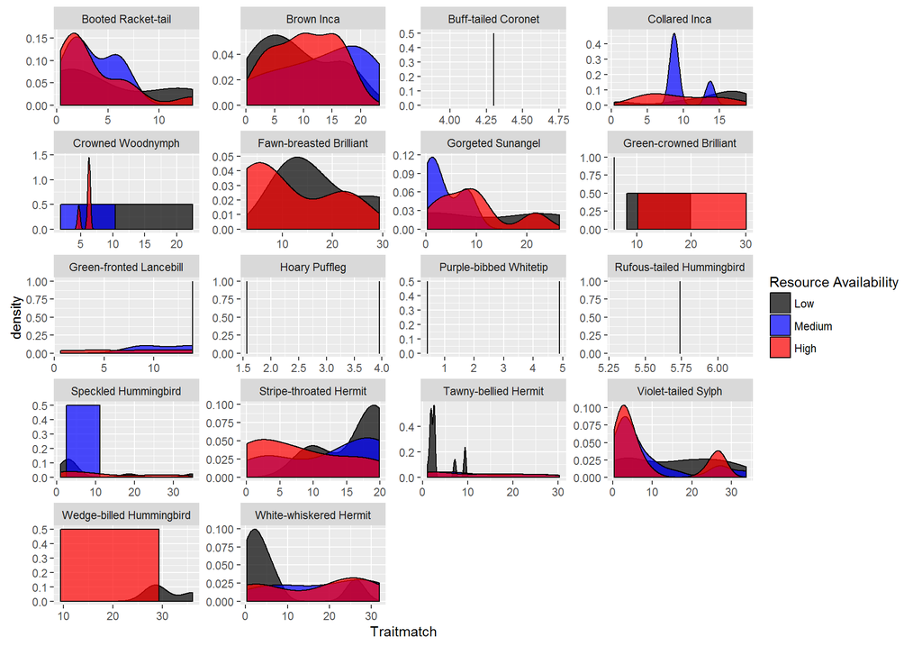

```r
ggplot(indat[indat$Yobs==1,],aes(x=Traitmatch,fill=as.factor(R))) + facet_wrap(~Hummingbird,ncol=4,scales="free") + geom_density(alpha=.7) + scale_fill_manual("Resource Availability",values=c("black",'blue','red'))
```

```r
m<-glmer(data=indat[,],Yobs~Traitmatch*R+(1|Hummingbird),family="poisson")
summary(m)
```

```
## Generalized linear mixed model fit by maximum likelihood (Laplace
##   Approximation) [glmerMod]
##  Family: poisson  ( log )
## Formula: Yobs ~ Traitmatch * R + (1 | Hummingbird)
##    Data: indat[, ]
##
##      AIC      BIC   logLik deviance df.resid
##   6879.3   6924.0  -3432.7   6865.3     4396
##
## Scaled residuals:
##     Min      1Q  Median      3Q     Max
## -2.0719 -0.5318 -0.3052 -0.1843 27.6204
##
## Random effects:
##  Groups      Name        Variance Std.Dev.
##  Hummingbird (Intercept) 2.15     1.466
## Number of obs: 4403, groups:  Hummingbird, 19
##
## Fixed effects:
##                     Estimate Std. Error z value Pr(>|z|)
## (Intercept)        -0.880082   0.346266  -2.542  0.01103 *
## Traitmatch         -0.040731   0.004882  -8.344  < 2e-16 ***
## RMedium            -0.277258   0.095587  -2.901  0.00372 **
## RHigh              -0.271769   0.088805  -3.060  0.00221 **
## Traitmatch:RMedium  0.004191   0.007201   0.582  0.56064
## Traitmatch:RHigh    0.006452   0.006667   0.968  0.33316
## ---
## Signif. codes:  0 '***' 0.001 '**' 0.01 '*' 0.05 '.' 0.1 ' ' 1
##
## Correlation of Fixed Effects:
##             (Intr) Trtmtc RMedim RHigh  Trt:RM
## Traitmatch  -0.142
## RMedium     -0.134  0.494
## RHigh       -0.147  0.547  0.515
## Trtmtch:RMd  0.099 -0.681 -0.741 -0.376
## Trtmtch:RHg  0.110 -0.748 -0.374 -0.744  0.514
```

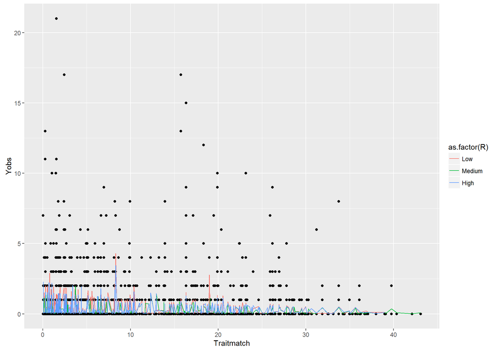

```r
indat$pred<-predict(m,type="response")
ggplot(indat,aes(x=Traitmatch)) + geom_point(aes(y=Yobs)) + geom_line(aes(y=pred,col=as.factor(R)))
```

# Hierarchical Occupancy Model

For hummingbird species i feeding on plant species j observed at time k and sampling event observed by transect (YTransect) or camera (YCamera)

Observation Model:

$YCamera_{i,j,k,d} \sim Binomial(N_{i,j,k},\omega_{Camera})$ $\omega_{Camera} <- \phi_{Camera} * EffortCamera_k$

Process Model:

$N_{i,j,k} \sim Poisson(\lambda_{i,j,k})$ $log(\lambda_{i,j,k}) = \alpha_i + \beta_{1,i} * Traitmatch_{i,j} + \beta_{2,i} *Resources_k + \beta_{3,i} * Traitmatch_{i,j} * Resources_k$

**Priors**

$\phi_{Camera} \sim U(0,1)$ $\alpha_i \sim Normal(\alpha_\mu,\alpha_\tau)$ $\beta_{1,i} \sim Normal(\mu_{\beta_1,\tau_{beta_1}})$ $\beta_{2,i} \sim Normal(\mu_{\beta_2,\tau_{beta_2}})$ $\beta_{3,i} \sim Normal(\mu_{\beta_3,\tau_{beta_3}})$

Group Level Variance $\tau_{\alpha} \sim Uniform(0,1000)$ $\tau_{\beta_1} \sim Uniform(0,1000)$ $\tau_{\beta_2} \sim Uniform(0,1000)$ $\tau_{\beta_3} \sim Uniform(0,1000)$

```r
#Source model
source("Bayesian/NmixturePoissonRagged2m.R")

#print model
writeLines(readLines("Bayesian/NmixturePoissonRagged2m.R"))
```

```
##
## sink("Bayesian/NmixturePoissonRagged2m.jags")
##
## cat("
##     model {
##     #Compute true state for each pair of birds and plants
##     for (i in 1:Birds){
##     for (j in 1:Plants){
##     for (k in 1:Times){
##
##     #Process Model
##     log(rho[i,j,k])<-alpha[i] + beta1[i] * Traitmatch[i,j] + beta2[i] * resources[i,j,k] + beta3[i] * resources[i,j,k] * Traitmatch[i,j]
##
##     #True State
##     S[i,j,k] ~ dpois(rho[i,j,k])
##     }
##     }
##     }
##
##     #Observation Model
##     for (x in 1:Nobs){
##
##     #Observation Process for cameras
##     Yobs_camera[x] ~ dbin(dcam[Bird[x]],S[Bird[x],Plant[x],Time[x]])
##
##     #     #Assess Model Fit - Posterior predictive check
##     #
##     #     #Fit discrepancy statistics
##          #Camera
##          eval_cam[x]<-dcam[Bird[x]]*S[Bird[x],Plant[x],Time[x]]
##          E[x]<-pow((Yobs_camera[x]-eval_cam[x]),2)/(eval_cam[x]+0.5)
##     #
##          ynew_cam[x]~dbin(dcam[Bird[x]], S[Bird[x],Plant[x],Time[x]])
##          E.new[x]<-pow((ynew_cam[x]-eval_cam[x]),2)/(eval_cam[x]+0.5)
##     }
##
##     #Priors
##     #Observation model
##     #Detect priors, logit transformed - Following lunn 2012 p85
##
```

[output cut: 45 more lines]

```
##     beta2_sigma<-pow(1/beta2_tau,0.5)
##
##     #Interaction
##     beta3_mu~dnorm(0,0.386)
##     beta3_tau ~ dunif(0,1000)
##     beta3_sigma<-pow(1/beta3_tau,0.5)
##
##     #derived posterior check
##     fit<-sum(E[]) #Discrepancy for the observed data
##     fitnew<-sum(E.new[])
##
##     }
##     ",fill=TRUE)
##
## sink()
```

```r
#Inits
InitStage <- function(){
  #A blank Y matrix - all present
  initY<-array(dim=c(Birds,Plants,Times),22)
  initB<-rep(0.5,Birds)
list(S=initY,dcam=initB)}

#Parameters to track
ParsStage <- c("alpha","beta1","beta2","beta3","alpha_mu","alpha_sigma","beta1_sigma","beta1_mu","beta2_mu","beta2_sigma","beta3_mu","beta3_sigma","dcam","dprior_cam","E","fit","fitnew")


#Jags Data
Dat<-list(
  Yobs_camera = indat$Camera,
  Birds=max(indat$jBird),
  Bird=indat$jBird,
  Plant=indat$jPlant,
  Time=indat$jID,
  Plants=max(indat$jPlant),
  Times=max(indat$jID),
  resources=resourceMatrix,
  Nobs=nrow(indat),
  Traitmatch=jTraitmatch)

  #MCMC options
  if(newModel){
    system.time(
      m2<-jags.parallel(data=Dat,parameters.to.save =ParsStage,inits=InitStage,model.file="Bayesian/NmixturePoissonRagged2m.jags",n.thin=2,n.iter=200000,n.burnin=199000,n.chains=2,DIC=F)
      )
  }
```

```
##     user   system  elapsed
##    11.67     3.55 25868.61
```

```r
#recompile if needed
runs<-100000

recompile(m2)

if(!newModel){
  system.time(m2<-update(m2,n.iter=runs,n.burnin=runs-2000,n.thin=2))
}
```

```r
#extract par to data.frame
pars_detect<-extract_par(m2,data=indat,Bird="jBird",Plant="jPlant")
```

## Assess Convergence

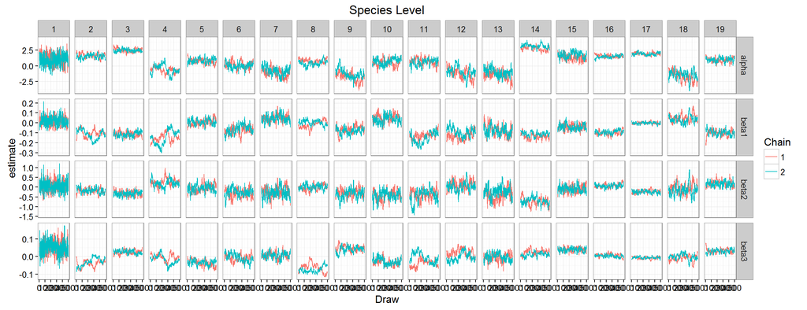

```r
###Chains
ggplot(pars_detect[pars_detect$par %in% c("alpha","beta1","beta2","beta3"),],aes(x=Draw,y=estimate,col=as.factor(Chain))) + geom_line() + facet_grid(par~species,scale="free") + theme_bw() + labs(col="Chain") + ggtitle("Species Level")
```

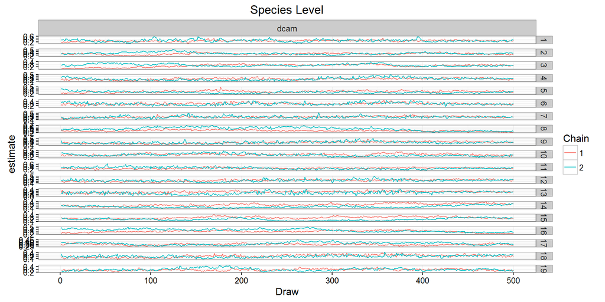

```r
ggplot(pars_detect[pars_detect$par %in% c("dcam"),],aes(x=Draw,y=estimate,col=as.factor(Chain))) + geom_line() + facet_grid(species~par,scale="free") + theme_bw() + labs(col="Chain") + ggtitle("Species Level")
```

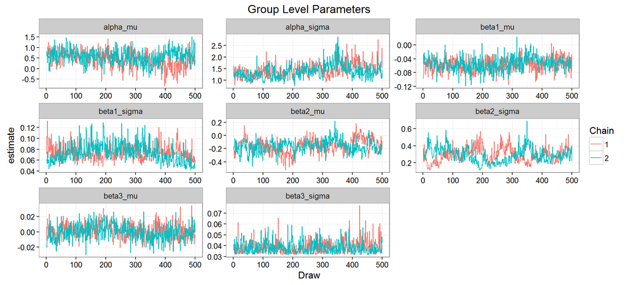

```r
ggplot(pars_detect[pars_detect$par %in% c("dcam_prior","beta1_mu","beta1_sigma","beta2_mu","beta2_sigma","beta3_mu","beta3_sigma","alpha_mu","alpha_sigma"),],aes(x=Draw,y=estimate,col=as.factor(Chain))) + geom_line() + theme_bw() + labs(col="Chain") + ggtitle("Group Level Parameters") + facet_wrap(~par,scales="free")
```

# Posteriors

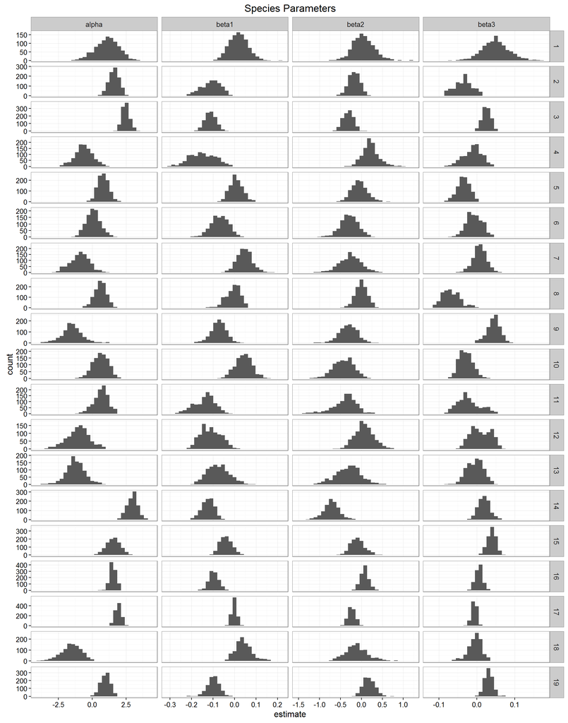

```r
###Posterior Distributions
ggplot(pars_detect[pars_detect$par %in% c("alpha","beta1","beta2","beta3"),],aes(x=estimate)) + geom_histogram(position='identity') +  facet_grid(species~par,scales="free") + theme_bw() + ggtitle("Species Parameters")
```

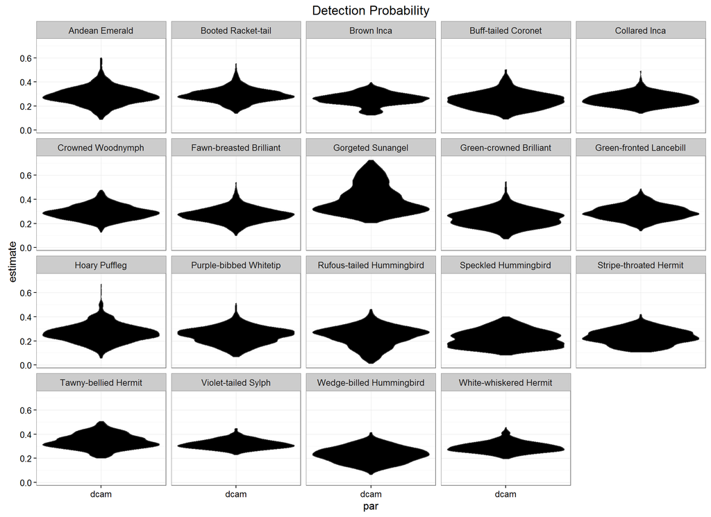

```r
#Detection figure
pars_detect<-merge(pars_detect,jagsIndexBird,by.x="species",by.y="jBird",all=T)
ggplot(pars_detect[pars_detect$par %in% "dcam",],aes(x=par,y=estimate)) + geom_violin(fill='black') + theme_bw() + ggtitle("Detection Probability") + facet_wrap(~Hummingbird)
```

# Detection Table

```r
detecttable<-group_by(pars_detect,Hummingbird,par) %>% filter(par %in% c('dcam')) %>% summarize(mean=mean(estimate),lower=quantile(estimate,0.05),upper=quantile(estimate,0.95))
detecttable
```

```
## Source: local data frame [19 x 5]
## Groups: Hummingbird [?]
##
##                  Hummingbird    par      mean      lower     upper
##                       (fctr) (fctr)     (dbl)      (dbl)     (dbl)
## 1             Andean Emerald   dcam 0.2860611 0.17136117 0.4105110
## 2         Booted Racket-tail   dcam 0.2890221 0.19532805 0.3897599
## 3                 Brown Inca   dcam 0.2569828 0.15722760 0.3386998
## 4        Buff-tailed Coronet   dcam 0.2481644 0.14480129 0.3660629
## 5              Collared Inca   dcam 0.2556361 0.18130857 0.3381944
## 6          Crowned Woodnymph   dcam 0.2911020 0.20251066 0.3911487
## 7    Fawn-breasted Brilliant   dcam 0.2719198 0.17733149 0.3688958
## 8          Gorgeted Sunangel   dcam 0.4022095 0.25667906 0.6354341
## 9    Green-crowned Brilliant   dcam 0.2455037 0.13798024 0.3583917
## 10   Green-fronted Lancebill   dcam 0.2917141 0.19944392 0.3959125
## 11             Hoary Puffleg   dcam 0.2655441 0.14756742 0.3992080
## 12    Purple-bibbed Whitetip   dcam 0.2441815 0.12510575 0.3493862
## 13 Rufous-tailed Hummingbird   dcam 0.2374721 0.08347294 0.3546936
## 14      Speckled Hummingbird   dcam 0.2190321 0.11890723 0.3412346
## 15    Stripe-throated Hermit   dcam 0.2339001 0.13114130 0.3334439
## 16      Tawny-bellied Hermit   dcam 0.3392147 0.24292128 0.4401455
## 17       Violet-tailed Sylph   dcam 0.3166280 0.26154705 0.3805806
## 18  Wedge-billed Hummingbird   dcam 0.2301664 0.12599314 0.3365271
## 19    White-whiskered Hermit   dcam 0.2914780 0.22908195 0.3673567
```

## Discrepancy

The goodness of fit is a measured as chi-squared. The expected value for each day is the detection rate * the estimate intensity of interactions. The expected value is compared to the observed value of the actual data. In addition, a replicate dataset is generated from the posterior predicted intensity. Better fitting models will have lower discrepancy values and be Better fitting models are smaller values and closer to the 1:1 line. A perfect model would be 0 discrepancy. This is unrealsitic given the stochasticity in the sampling processes. Rather, its better to focus on relative discrepancy. In addition, a model with 0 discrepancy would likely be seriously overfit and have little to no predictive power.

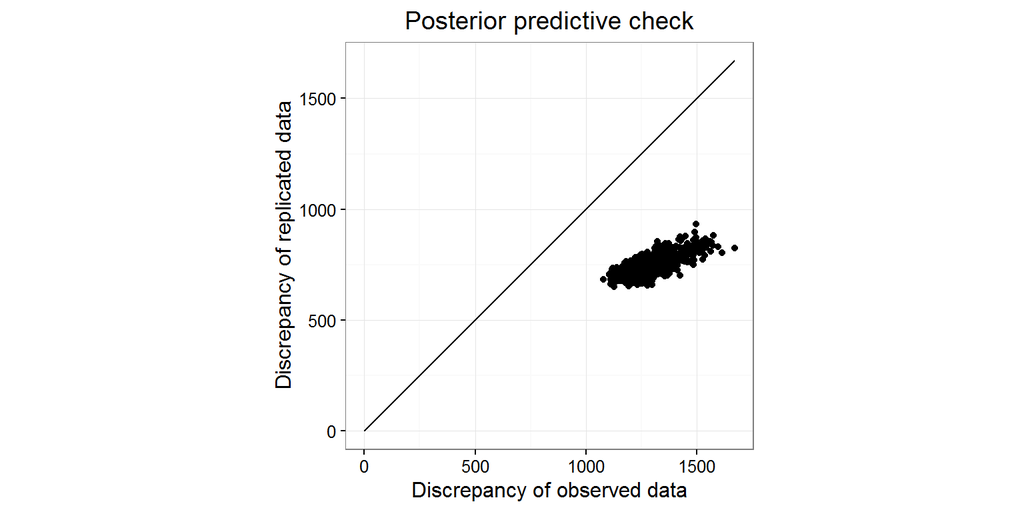

```r
fitstat<-pars_detect[pars_detect$par %in% c("fit","fitnew"),]
fitstat<-dcast(fitstat,Draw+Chain~par,value.var="estimate")

ymin<-round(min(fitstat$fit))
ymax<-round(max(fitstat$fit))
ab<-data.frame(x=0:ymax,y=0:ymax)
disc_obs<-ggplot(fitstat,aes(x=fit,y=fitnew)) + geom_point() + theme_bw() + labs(x="Discrepancy of observed data",y="Discrepancy of replicated data",col="Model")  + ggtitle("Posterior predictive check") + geom_line(data=ab,aes(x=x,y=y)) + coord_fixed() + ylim(ymin=0,ymax=max(max(c(fitstat$fit,fitstat$fitnew)))) + xlim(xmin=0,xmax=max(max(c(fitstat$fit,fitstat$fitnew))))
disc_obs
```

```r
#Bayesian p-value
sum(fitstat$fitnew>fitstat$fit)/nrow(fitstat)
```

```
## [1] 0
```

```r
ggsave("Figures/ObservedDiscrepancy.jpeg",width = 5,height=10)
```

# Predicted Relationship

```r
#Expand out pars
castdf<-dcast(pars_detect[pars_detect$par %in% c("beta1_mu","beta2_mu","beta3_mu","alpha_mu"),], Chain + Draw~par,value.var="estimate")
```

## Posterior prediction

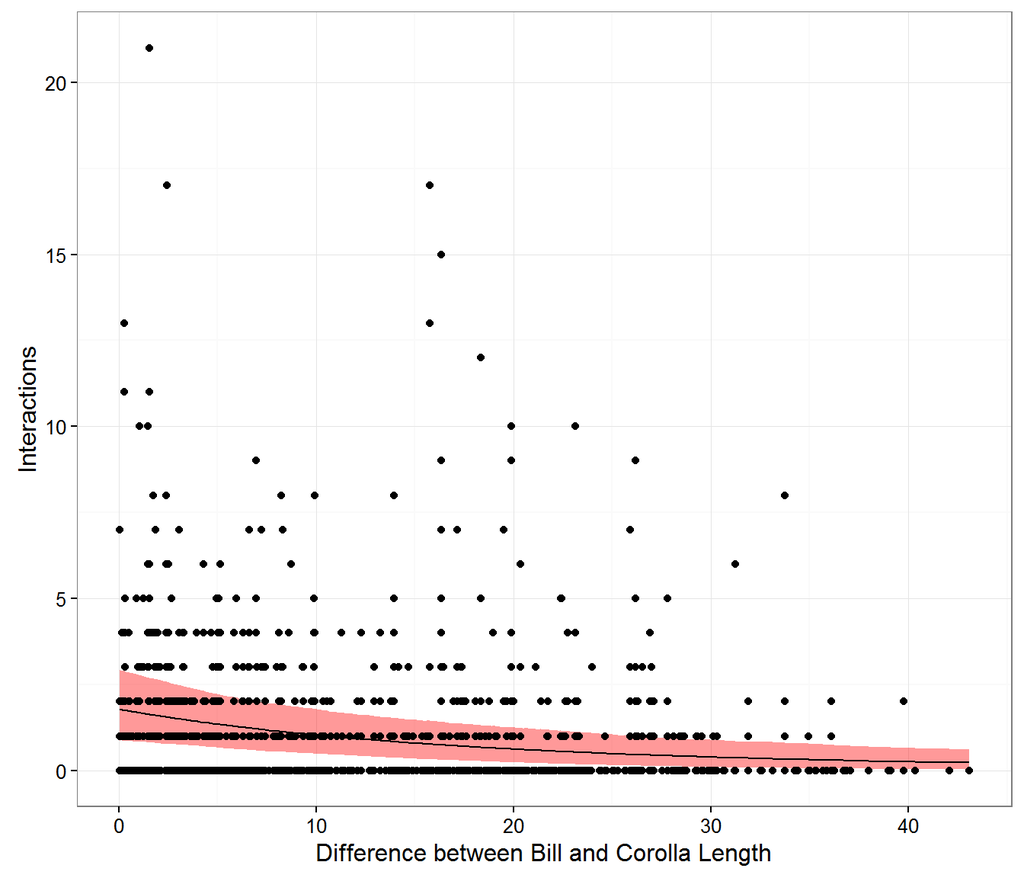

```r
#Trajectories from posterior
predy<-trajF(alpha=castdf$alpha_mu,beta1=castdf$beta1_mu,trait=indat$Traitmatch,resources=indat$scaledR,beta2=castdf$beta2_mu,beta3=castdf$beta3_mu)

ggplot(data=predy,aes(x=trait)) + geom_ribbon(aes(ymin=lower,ymax=upper),alpha=0.4,fill="red")  +  theme_bw() + ylab("Interactions") + xlab("Difference between Bill and Corolla Length") + geom_point(data=indat,aes(x=Traitmatch,y=Camera)) + geom_line(aes(y=mean)) + geom_point(data=indat,aes(x=Traitmatch,y=Transect))
```

## At High and Low Resource Availability

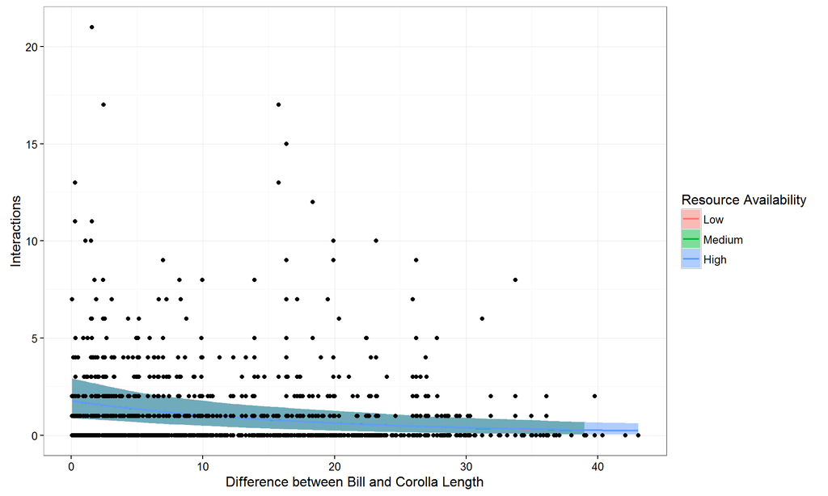

```r
#Trajectories from posterior
predH<-trajF(alpha=castdf$alpha_mu,beta1=castdf$beta1_mu,trait=indat[indat$R=="High","Traitmatch"],resources=indat[indat$R=="High","scaledR"],beta2=castdf$beta2_mu,beta3=castdf$beta3_mu)

predM<-trajF(alpha=castdf$alpha_mu,beta1=castdf$beta1_mu,trait=indat[indat$R=="Medium","Traitmatch"],resources=indat[indat$R=="Medium","scaledR"],beta2=castdf$beta2_mu,beta3=castdf$beta3_mu)

predL<-trajF(alpha=castdf$alpha_mu,beta1=castdf$beta1_mu,trait=indat[indat$R=="Low","Traitmatch"],resources=indat[indat$R=="Low","scaledR"],beta2=castdf$beta2_mu,beta3=castdf$beta3_mu)

predhl<-melt(list(High=predH,Medium=predM,Low=predL),id.vars=colnames(predH))

colnames(predhl)[5]<-"BFlowerL"

predhl$BFlowerL<-factor(as.character(predhl$BFlowerL))
levels(predhl$BFlowerL)<-c("Low","Medium","High")

ggplot(data=predhl,aes(x=trait)) + geom_ribbon(aes(ymin=lower,ymax=upper,fill=BFlowerL),alpha=0.5)  + geom_line(aes(y=mean,col=BFlowerL),size=.8) + theme_bw() + ylab("Interactions") + xlab("Difference between Bill and Corolla Length") + geom_point(data=mindat,aes(x=Traitmatch,y=value))+ labs(fill="Resource Availability",col="Resource Availability")
```

```r
ggsave("Figures/AllRegression.jpeg",height=5,width=7)
```

## Species Predictions

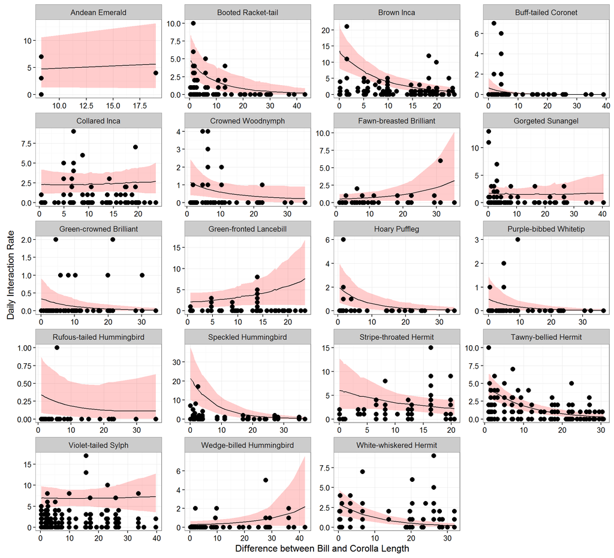

```r
castdf<-dcast(pars_detect[pars_detect$par %in% c("beta1","beta2","beta3","alpha"),], species +Chain +Draw ~par ,value.var="estimate")

#Turn to
castdf$species<-factor(castdf$species,levels=1:max(as.numeric(castdf$species)))

species.split<-split(castdf,list(castdf$species),drop = T)

species.traj<-list()

for(d in 1:length(species.split)){
  x<-species.split[[d]]
  index<-unique(x$species)

  #get data for those species
  billd<-indat[indat$jBird %in% index,]

  #scale resources
  species.traj[[d]]<-trajF(alpha=x$alpha,beta1=x$beta1,beta2=x$beta2,beta3=x$beta3,resources=billd$scaledR,trait=billd$Traitmatch)
  }

names(species.traj)<-names(species.split)

species.traj<-melt(species.traj,id.var=colnames(species.traj[[1]]))

#split out names and model
species.traj[,c("Index")]<-colsplit(species.traj$L1,"\\.",c("Index"))

spe<-merge(species.traj,jagsIndexBird,by.x="Index",by.y="jBird")

#plot and compare to original data
ggplot(data=spe,aes(x=trait)) + geom_ribbon(aes(ymin=lower,ymax=upper),alpha=0.2,fill='red') + geom_line(aes(y=mean),size=.5) + theme_bw() + ylab("Daily Interaction Rate")+ xlab("Difference between Bill and Corolla Length") + facet_wrap(~Hummingbird,scales="free",ncol=4) + geom_point(data=mindat,aes(x=Traitmatch,y=value),size=2.5)
```

### Species Predictions: High and Low Availability

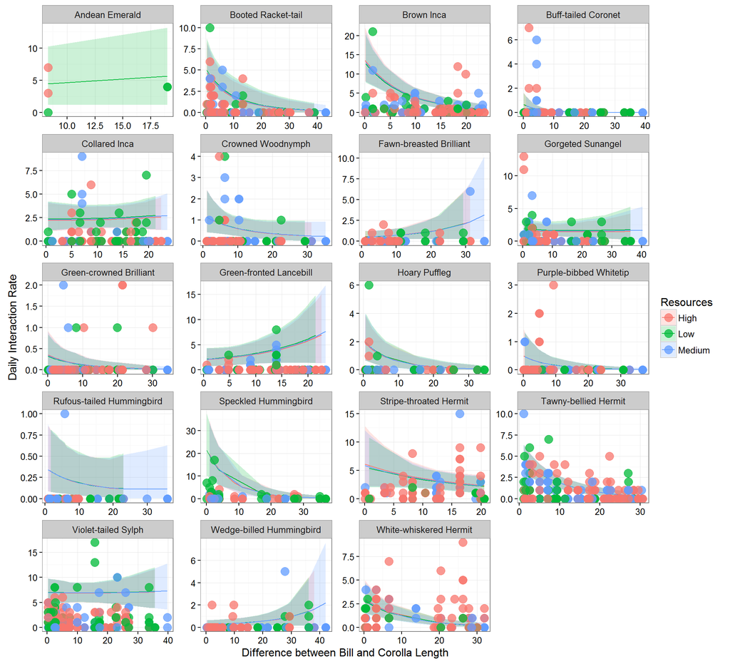

```r
castdf<-dcast(pars_detect[pars_detect$par %in% c("beta1","beta2","beta3","alpha"),], species +Chain +Draw ~par ,value.var="estimate")

#Turn to
castdf$species<-factor(castdf$species,levels=1:max(as.numeric(castdf$species)))

species.split<-split(castdf,list(castdf$species),drop = T)

species.traj<-list()

for(d in 1:length(species.split)){
  x<-species.split[[d]]
  index<-unique(x$species)

  #get data for those species
  billd<-indat[indat$jBird %in% index,]

  sh<-trajF(alpha=x$alpha,beta1=x$beta1,beta2=x$beta2,beta3=x$beta3,resources=billd[billd$R=="High","scaledR"],trait=billd[billd$R=="High","Traitmatch"])

  sm<-trajF(alpha=x$alpha,beta1=x$beta1,beta2=x$beta2,beta3=x$beta3,resources=billd[billd$R=="Medium","scaledR"],trait=billd[billd$R=="Medium","Traitmatch"])

  sl<-trajF(alpha=x$alpha,beta1=x$beta1,beta2=x$beta2,beta3=x$beta3,resources=billd[billd$R=="Low","scaledR"],trait=billd[billd$R=="Low","Traitmatch"])

  sm<-melt(list(High=sh,Medium=sm,Low=sl),id.vars=colnames(sl))
  colnames(sm)[5]<-"Resources"
  species.traj[[d]]<-sm
  }

names(species.traj)<-names(species.split)

species.traj<-melt(species.traj,id.var=colnames(species.traj[[1]]))

#split out names and model
species.traj[,c("Index")]<-colsplit(species.traj$L1,"\\.",c("Index"))

spe<-merge(species.traj,jagsIndexBird,by.x="Index",by.y="jBird")

#plot and compare to original data
indat$rplot<-as.factor(indat$scaledR)
levels(indat$rplot)<-c("Low","Medium","High")
ggplot(data=spe,aes(x=trait)) + geom_ribbon(aes(ymin=lower,ymax=upper,fill=Resources),alpha=0.2) + geom_line(aes(y=mean,col=Resources),size=.5) + theme_bw() + ylab("Daily Interaction Rate")+ xlab("Difference between Bill and Corolla Length") + facet_wrap(~Hummingbird,scales="free",ncol=4) + geom_point(data=indat,aes(x=Traitmatch,y=Yobs,col=rplot),size=4,alpha=.75)
```

```r
ggsave("Figures/SpeciesRegression.jpeg",height=6,width=7)
```

## Species Level Interaction

```r
castdf<-dcast(pars_detect[pars_detect$par %in% c("beta1","beta2","beta3","alpha"),], species +Chain + Draw~par,value.var="estimate")

#Turn to
castdf$species<-factor(castdf$species,levels=1:max(as.numeric(castdf$species)))

species.split<-split(castdf,list(castdf$species),drop = T)

species.traj<-list()

for(d in 1:length(species.split)){
  dat<-species.split[[d]]
  index<-unique(dat$species)

  #get data for those species
  billd<-mindat[mindat$jBird %in% index,]

  #Calculate interaction effect
  species.traj[[d]]<-intF(alpha=dat$alpha,beta1=dat$beta1,x=billd[billd$value > 0 & !is.na(billd$value),'Traitmatch'],resources=billd[billd$value > 0 & !is.na(billd$value),'scaledR'],beta2=dat$beta2,beta3=dat$beta3)
  }

names(species.traj)<-names(species.split)
species.traj<-melt(species.traj,id.var=colnames(species.traj[[1]]))

#split out names and model
species.traj[,c("Index")]<-colsplit(species.traj$L1,"\\.",c("Index"))

spe<-merge(species.traj,jagsIndexBird,by.x="Index",by.y="jBird")

#match colnames

#plot and compare to original data
ggplot(data=spe,aes(x=x)) + geom_ribbon(aes(ymin=lower,ymax=upper,fill=Hummingbird),alpha=0.3) + geom_line(aes(y=mean,col=Hummingbird),size=1) + theme_bw() + xlab("Difference between Bill and Corolla Length")  + ylab("Effect of Resources on Trait Difference") + facet_wrap(~Hummingbird,scales="free",ncol=3)
ggsave("Figures/SpeciesInteraction.jpeg",height=6,width=7)
```

[output not shown]

## Which species did we predict well?

```r
smat<-pars_detect %>% filter(par=="E") %>% group_by(species) %>% summarize(fit=sum(estimate)) %>% arrange(desc(fit))
smat<-merge(smat,jagsIndexBird,by.x="species",by.y="jBird")
smat
```

```
##    species        fit               Hummingbird
## 1        1   4151.261            Andean Emerald
## 2        2  84118.304        Booted Racket-tail
## 3        3 191793.825                Brown Inca
## 4        4  36400.080       Buff-tailed Coronet
## 5        5  96336.164             Collared Inca
## 6        6  26162.291         Crowned Woodnymph
## 7        7  17121.888   Fawn-breasted Brilliant
## 8        8  58591.404         Gorgeted Sunangel
## 9        9  13458.026   Green-crowned Brilliant
## 10      10  53079.257   Green-fronted Lancebill
## 11      11  14235.714             Hoary Puffleg
## 12      12  14105.918    Purple-bibbed Whitetip
## 13      13   1332.604 Rufous-tailed Hummingbird
## 14      14  87277.913      Speckled Hummingbird
## 15      15 103223.433    Stripe-throated Hermit
## 16      16 135700.458      Tawny-bellied Hermit
## 17      17 234775.680       Violet-tailed Sylph
## 18      18  24124.479  Wedge-billed Hummingbird
## 19      19  85051.099    White-whiskered Hermit
```

## Discrepancy matrix

```r
dmat<-pars_detect %>% filter(par=="E") %>% group_by(species,plant) %>% summarize(fit=sum(estimate)) %>% arrange(desc(fit))
dmat<-merge(dmat,jagsIndexBird,by.x="species",by.y="jBird")
dmat<-merge(dmat,jagsIndexPlants,by.x="plant",by.y="jPlant")
head(dmat,10)
```

```
##    plant species        fit              Hummingbird
## 1      1      12   57.32709   Purple-bibbed Whitetip
## 2      1      10  248.08465  Green-fronted Lancebill
## 3      1       9   36.31378  Green-crowned Brilliant
## 4      1       5  632.47404            Collared Inca
## 5      1       6   46.80679        Crowned Woodnymph
## 6      1       8   93.87600        Gorgeted Sunangel
## 7      1      17 1782.85528      Violet-tailed Sylph
## 8      1      18   38.60655 Wedge-billed Hummingbird
## 9      1       2   60.05844       Booted Racket-tail
## 10     1      16 1571.71090     Tawny-bellied Hermit
##                Iplant_Double
## 1  Alloplectus tetragonoides
## 2  Alloplectus tetragonoides
## 3  Alloplectus tetragonoides
## 4  Alloplectus tetragonoides
## 5  Alloplectus tetragonoides
## 6  Alloplectus tetragonoides
## 7  Alloplectus tetragonoides
## 8  Alloplectus tetragonoides
## 9  Alloplectus tetragonoides
## 10 Alloplectus tetragonoides
```

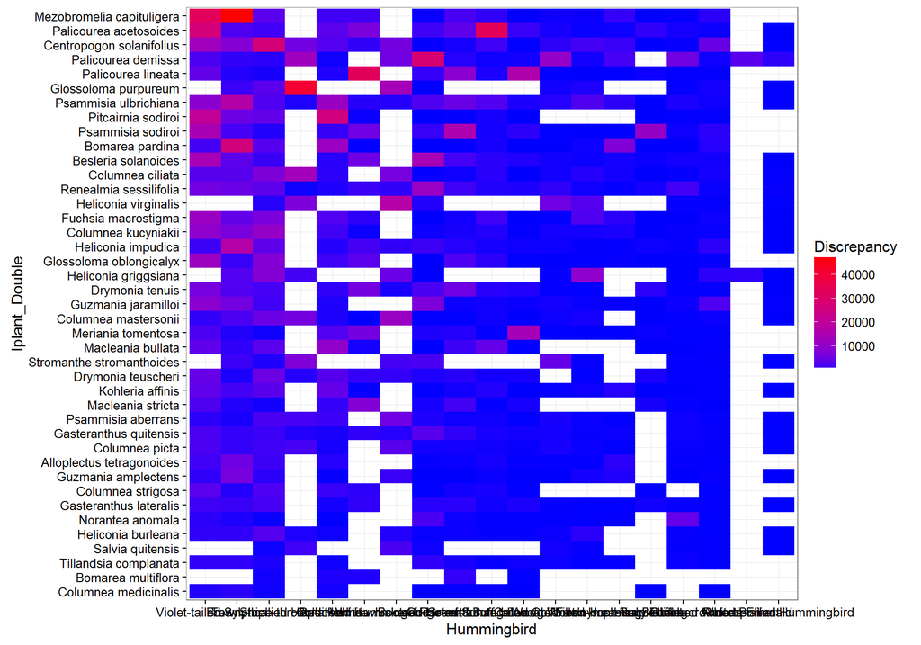

```r
#get order
hord<-dmat %>% group_by(Hummingbird) %>% summarize(n=sum(fit)) %>% arrange(desc(n)) %>% .$Hummingbird
pord<-dmat %>% group_by(Iplant_Double) %>% summarize(n=sum(fit)) %>% arrange(n) %>%  .$Iplant_Double
dmat$Hummingbird<-factor(dmat$Hummingbird,levels=hord)
dmat$Iplant_Double<-factor(dmat$Iplant_Double,levels=pord)
ggplot(dmat,aes(x=Hummingbird,Iplant_Double,fill=fit)) + geom_tile() + theme_bw() + scale_fill_continuous("Discrepancy",low="blue",high="red")
```

## Resource Abundance Functions

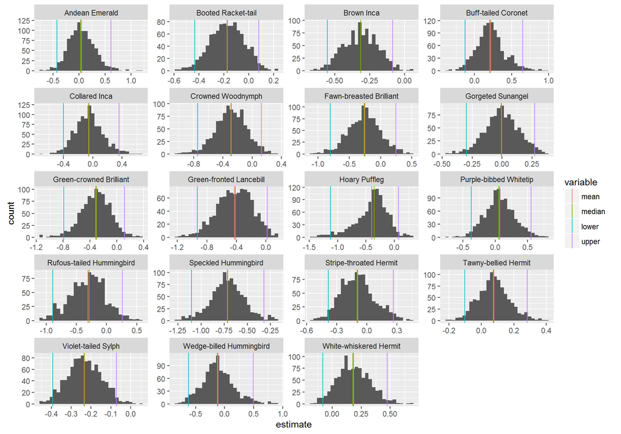

```r
post<-pars_detect %>% filter(par %in% "beta2") %>% group_by(Hummingbird) %>% summarize(mean=mean(estimate),median=median(estimate),lower=quantile(probs=0.025,estimate),upper=quantile(probs=0.975,estimate)) %>% melt(id.vars='Hummingbird')
ggplot(pars_detect[pars_detect$par %in% "beta2",],aes(x=estimate)) + geom_histogram() + facet_wrap(~Hummingbird,scales='free',ncol=4) + geom_vline(data=post,aes(xintercept=value,col=variable))
```

## Interaction density functions

Let’s take a closer look at distribution of interaction effect posteriors values for each species.

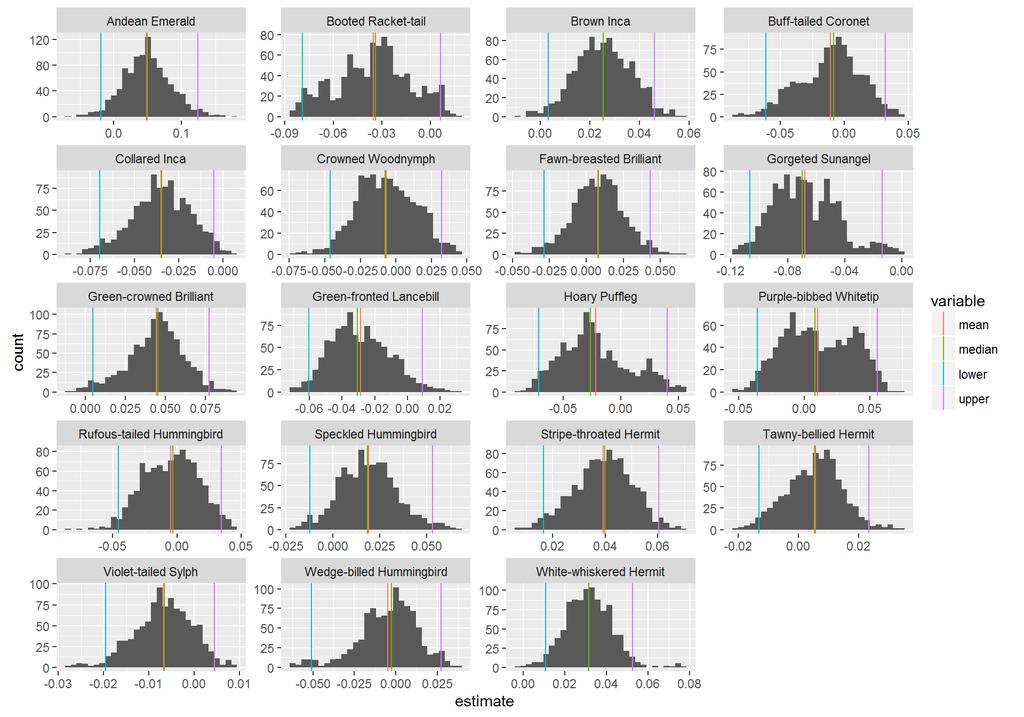

```r
post<-pars_detect %>% filter(par %in% "beta3") %>% group_by(Hummingbird) %>% summarize(mean=mean(estimate),median=median(estimate),lower=quantile(probs=0.025,estimate),upper=quantile(probs=0.975,estimate)) %>% melt(id.vars='Hummingbird')
ggplot(pars_detect[pars_detect$par %in% "beta3",],aes(x=estimate)) + geom_histogram() + facet_wrap(~Hummingbird,scales='free',ncol=4) + geom_vline(data=post,aes(xintercept=value,col=variable))
```

## Trait-matching and Bill Length

Do species with long bill lengths have positive traitmatching effects?

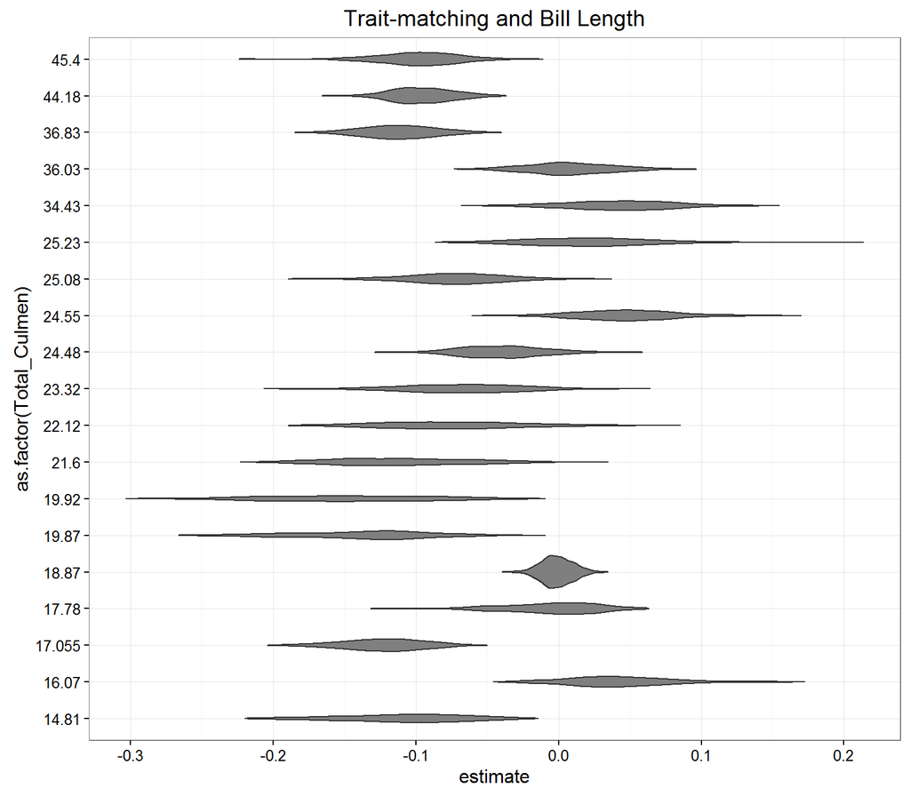

```r
#species names
b<-pars_detect[pars_detect$par %in% "beta1",]

#traits
b<-merge(b,hum.morph,by.x="Hummingbird",by.y="English")

post<-b %>% filter(par %in% "beta1") %>% group_by(Hummingbird) %>% summarize(mean=mean(estimate),median=median(estimate),lower=quantile(probs=0.025,estimate),upper=quantile(probs=0.975,estimate),quantile_l=quantile(estimate)[[1]],quantile_u=quantile(estimate)[[2]]) %>% melt(id.vars='Hummingbird')

#get order of mean posterior
ord<-post %>% filter(variable=="mean") %>% arrange(value) %>% .$Hummingbird

b$Hummingbird<-factor(b$Hummingbird,levels=ord)
ggplot(b,aes(y=estimate,x=as.factor(Total_Culmen),group=Hummingbird)) + geom_violin(fill='grey50') + coord_flip()  + ggtitle("Trait-matching and Bill Length") + theme_bw()
```

## Interaction and Bill Length

Do species with long bill lengths have positive interaction effects?

```r
#species names
b<-pars_detect[pars_detect$par %in% "beta3",]

#traits
b<-merge(b,hum.morph,by.x="Hummingbird",by.y="English")

post<-b %>% filter(par %in% "beta3") %>% group_by(Hummingbird) %>% summarize(mean=mean(estimate),median=median(estimate),lower=quantile(probs=0.025,estimate),upper=quantile(probs=0.975,estimate),quantile_l=quantile(estimate)[[1]],quantile_u=quantile(estimate)[[2]]) %>% melt(id.vars='Hummingbird')

#get order of mean posterior
ord<-post %>% filter(variable=="mean") %>% arrange(value) %>% .$Hummingbird

b$Hummingbird<-factor(b$Hummingbird,levels=ord)
ggplot(b,aes(y=estimate,x=Hummingbird,fill=Total_Culmen)) + geom_violin() + coord_flip() + scale_fill_continuous(low='blue',high='red') + ggtitle("Interaction Effect and Bill Length") + theme_bw()
```

[output not shown]

# Estimated niche breadth

```r
castdf<-dcast(pars_detect[pars_detect$par %in% c("beta1","beta2","beta3","alpha"),], species +Chain + Draw~par,value.var="estimate")

#Turn to
castdf$species<-factor(castdf$species,levels=1:max(as.numeric(castdf$species)))

species.split<-split(castdf,list(castdf$species),drop = T)

species.traj<-lapply(species.split,function(dat){
  index<-unique(dat$species)

  #get data for those species
  billd<-indat[indat$jBird %in% index,]

  d<-data.frame(alpha=dat$alpha,beta1=dat$beta1,beta2=dat$beta2,beta3=dat$beta3)

  #fit regression for each input estimate
  sampletraj<-list()

  for (y in 1:nrow(d)){
    v=exp(d$alpha[y] + d$beta1[y] * billd$Traitmatch + d$beta2[y] * billd$scaledR + d$beta3[y] * billd$Traitmatch*billd$scaledR)

    sampletraj[[y]]<-data.frame(x=as.numeric(billd$Traitmatch),y=as.numeric(v),r=as.numeric(billd$scaledR),jBird=billd$jBird,jPlant=billd$jPlant,jTime=billd$jTime)
  }

  sample_all<-rbind_all(sampletraj)
})

species.traj<-rbind_all(species.traj)
```

Mean Estimates for Corolla Sizes

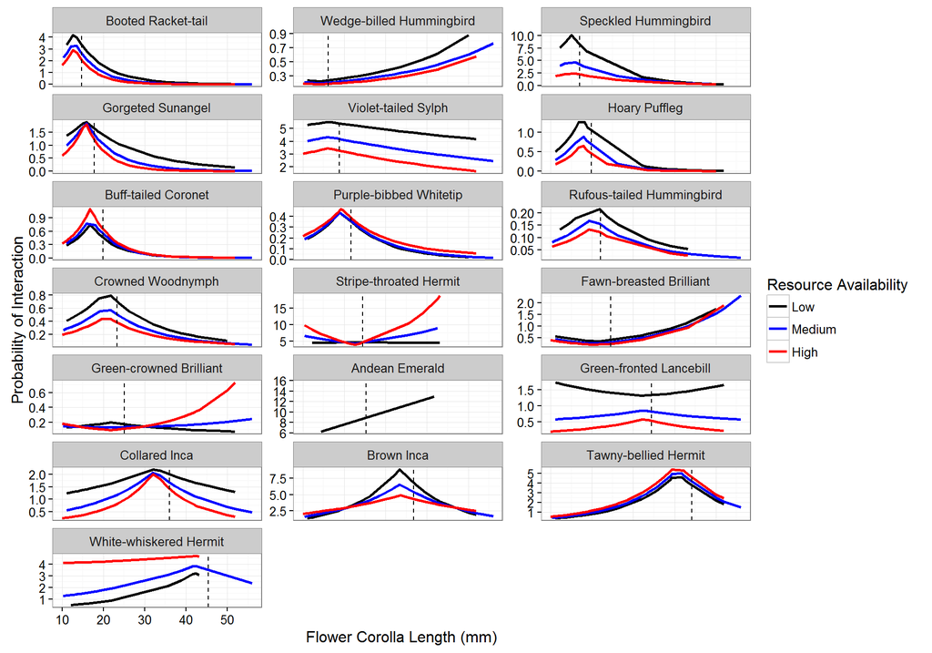

```r
species.mean<-species.traj %>% group_by(jBird,jPlant,r) %>% summarize(Traitmatch=unique(x),phi=mean(y))

tomerge<-indat %>% select(jBird,jPlant,Hummingbird,Iplant_Double) %>% distinct()

species.mean<-merge(species.mean,tomerge)

#get corolla sizes
species.mean<-merge(species.mean,fl.morph,by.x="Iplant_Double", by.y="Group.1")

#bill order
ord<-hum.morph %>% arrange(Total_Culmen) %>% .$English
species.mean$Hummingbird<-factor(species.mean$Hummingbird,levels=ord)

#add level to hum.morph to match naming convention
species.mean<-merge(species.mean,hum.morph[,c("English","Total_Culmen")],by.x="Hummingbird",by.y="English")

p<-ggplot(species.mean,aes(x=Corolla,y=phi,col=as.factor(r))) + geom_line(size=.9) + geom_vline(aes(xintercept=Total_Culmen),linetype='dashed') + facet_wrap(~Hummingbird,ncol=3,scales="free_y")  + theme_bw() + ylab("Probability of Interaction") + scale_color_manual("Resource Availability",labels=c("Low","Medium","High"),values=c("Black","Blue","Red")) + xlab("Flower Corolla Length (mm)")
p
```

```r
ggsave("Figures/ResponseCurves.jpeg",height=6.5,width=9)
```

# Niche Breadth

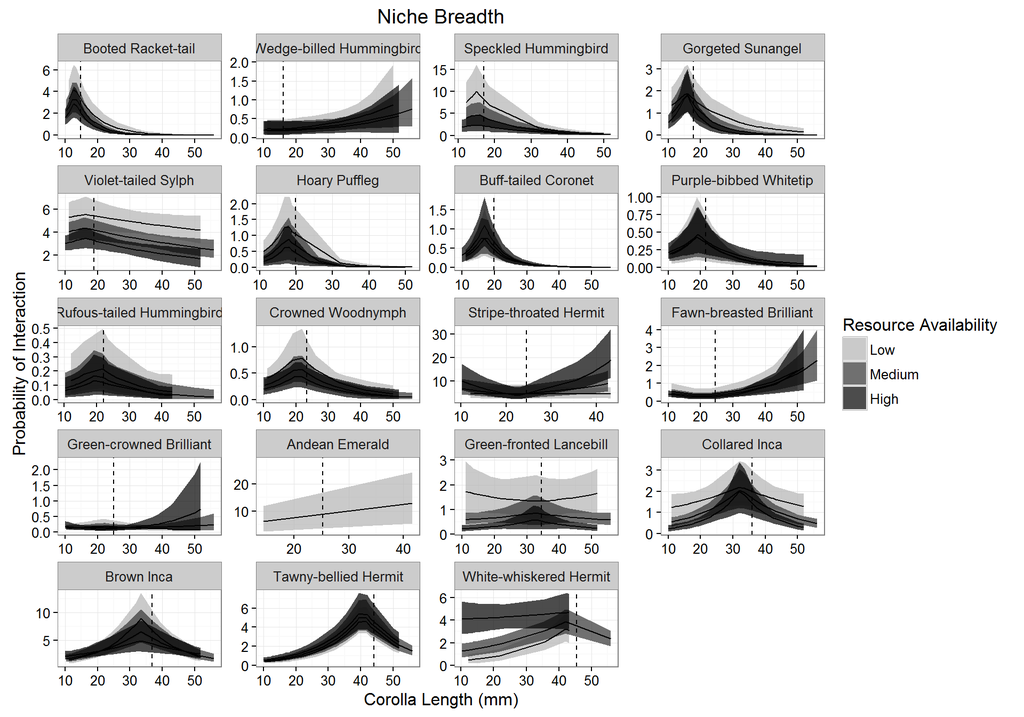

```r
species.mean<-species.traj %>% group_by(jBird,jPlant,r) %>% summarize(Traitmatch=unique(x),phi=mean(y),phi_low=quantile(y,0.05),phi_high=quantile(y,0.95))

#merge names
species.mean<-merge(species.mean,jagsIndexBird)
species.mean<-merge(species.mean,jagsIndexPlants)

#get corolla sizes
species.mean<-merge(species.mean,fl.morph,by.x="Iplant_Double", by.y="Group.1")

#bill order
ord<-hum.morph %>% arrange(Total_Culmen) %>% .$English
species.mean$Hummingbird<-factor(species.mean$Hummingbird,levels=ord)

#add level to hum.morph to match naming convention
species.mean<-merge(species.mean,hum.morph[,c("English","Total_Culmen")],by.x="Hummingbird",by.y="English")

#label factor
species.mean$r<-as.factor(species.mean$r)
levels(species.mean$r)<-c("Low","Medium","High")
ggplot(species.mean) + geom_ribbon(alpha=0.7,aes(x=Corolla,ymin=phi_low,ymax=phi_high,fill=r)) + theme_bw() + facet_wrap(~Hummingbird,scales="free",ncol=4)+ ggtitle("Niche Breadth") + geom_vline(aes(xintercept=Total_Culmen),linetype='dashed') + geom_line(aes(x=Corolla,y=phi,fill=r)) + ylab("Probability of Interaction") + xlab("Corolla Length (mm)") + scale_fill_manual("Resource Availability",values=c("Grey70","Grey20","Black"))
```

```r
ggsave("Figures/NicheBreadth.jpeg",height=8,width=9)
```

## Range plots

```r
nsplit<-split(species.mean,species.mean$r)
makeR<-function(x){

  #input matrix
  aggm<-matrix(nrow=nrow(jagsIndexBird),ncol=nrow(jagsIndexPlants),data=0)
  for (j in 1:nrow(x)){
    aggm[x[j,"jBird"],x[j,"jPlant"]]<-rpois(1,lambda=x[j,"phi"])
  }

  aggm<-melt(aggm)
  colnames(aggm)<-c("jBird","jPlant","P")
  tomerge<-species.mean %>% select(jBird,jPlant,Corolla,Hummingbird,Traitmatch) %>% distinct()
  aggm<-merge(aggm,tomerge)
  return(aggm)
}

nstat<-lapply(nsplit,function(x){
  netstat<-melt(lapply(1:50,function(k) makeR(x)),id.vars=c("jBird","jPlant","Hummingbird","Traitmatch","Corolla","P"))
  colnames(netstat)[7]<-"Iteration"
  return(netstat)
})

names(nstat)<-c("Low","Medium","High")
nstat<-melt(nstat,colnames(nstat[[1]]))
```

Predicted density

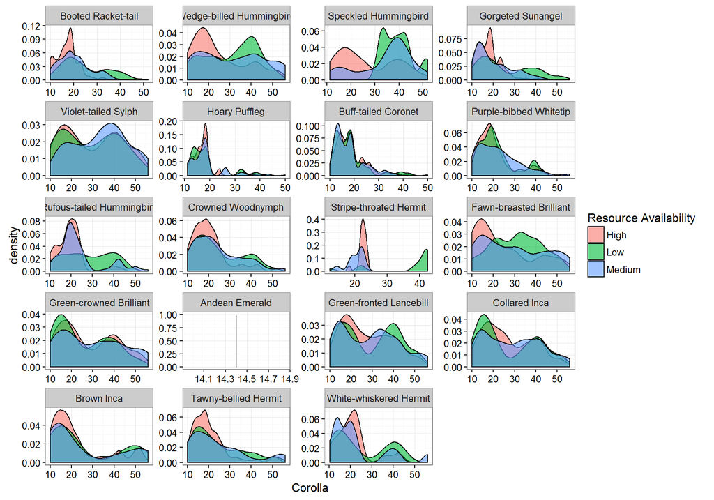

```r
ggplot(nstat[nstat$P==1,],aes(x=Corolla,fill=L1)) + geom_density(alpha=0.6) + facet_wrap(~Hummingbird,scales='free',nrow=5) + scale_fill_discrete("Resource Availability") + theme_bw()
```

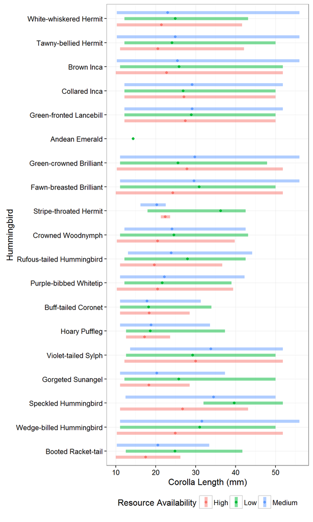

```r
rangestat<-nstat %>% filter(P==1) %>% group_by(Hummingbird,L1) %>% summarize(mean=mean(Corolla),lower=quantile(Corolla,0.05),upper=quantile(Corolla,0.95))

ggplot(rangestat,aes(x=Hummingbird,ymin=lower,ymax=upper,ymean=mean,col=L1)) + geom_linerange(alpha=0.5,position=position_dodge(width=.75),size=2) + geom_point(aes(y=mean),position=position_dodge(width=.75)) + labs(col="Resource Availability",y="Corolla Length (mm)") + theme_bw() + coord_flip() + theme(legend.position="bottom")
```

### Predicted Mean

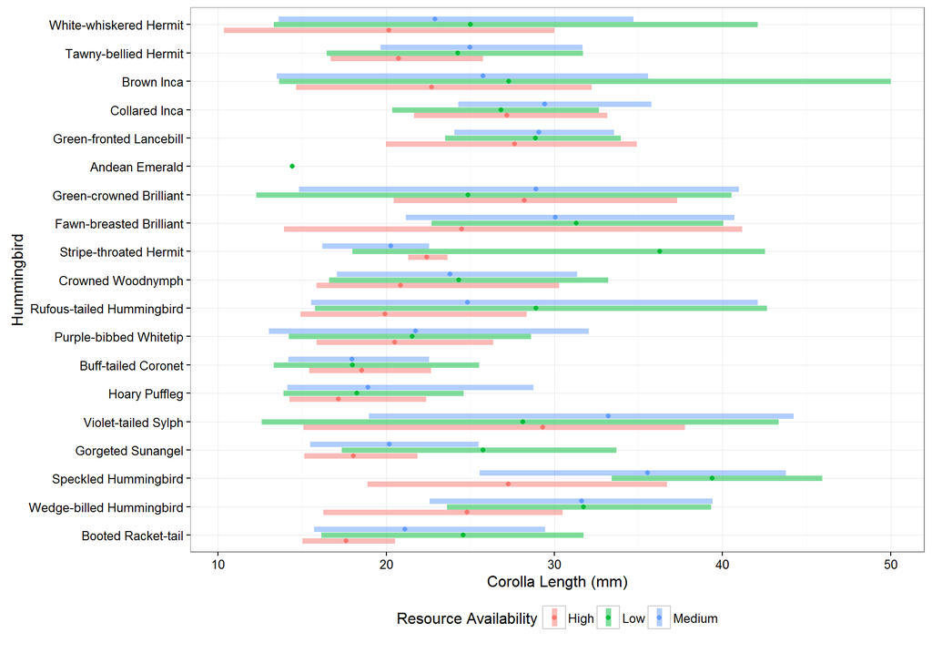

```r
meanstat<-nstat %>% filter(P==1) %>% group_by(Hummingbird,L1,Iteration) %>% summarize(a=mean(Corolla))%>% summarize(mean=mean(a),lower=quantile(a,0.05),upper=quantile(a,0.95))

ggplot(meanstat,aes(x=Hummingbird,ymin=lower,ymax=upper,ymean=mean,col=L1)) + geom_linerange(alpha=0.5,position=position_dodge(width=.6),size=2) + geom_point(aes(y=mean),position=position_dodge(width=.6)) + labs(col="Resource Availability",y="Corolla Length (mm)") + theme_bw() + coord_flip() + theme(legend.position="bottom")
```

### Predicted Min

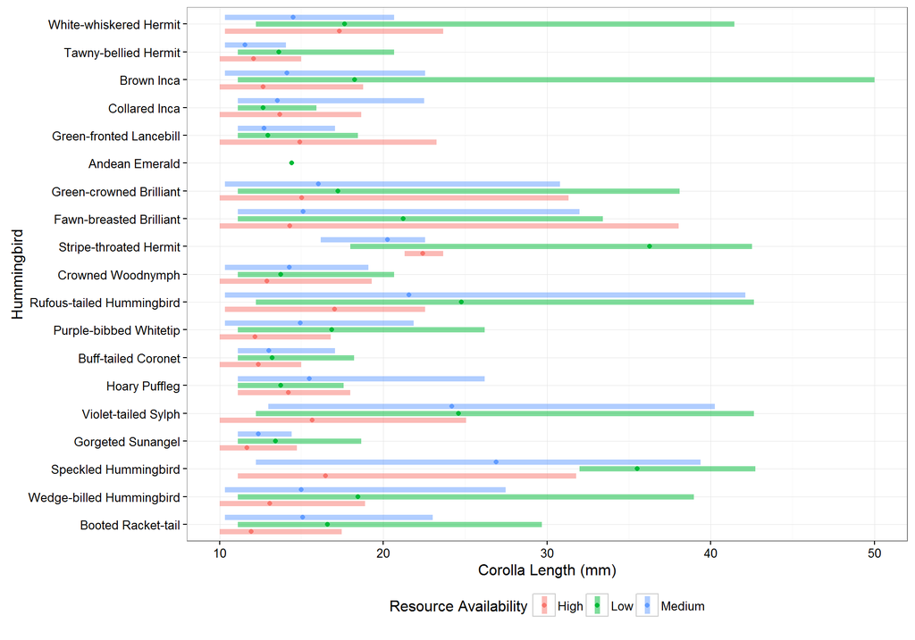

```r
meanstat<-nstat %>% filter(P==1) %>% group_by(Hummingbird,L1,Iteration) %>% summarize(a=min(Corolla))%>% summarize(mean=mean(a),lower=quantile(a,0.05),upper=quantile(a,0.95))

ggplot(meanstat,aes(x=Hummingbird,ymin=lower,ymax=upper,ymean=mean,col=L1)) + geom_linerange(alpha=0.5,position=position_dodge(width=.75),size=2) + geom_point(aes(y=mean),position=position_dodge(width=.75)) + labs(col="Resource Availability",y="Corolla Length (mm)") + theme_bw() + coord_flip() + theme(legend.position="bottom")
```

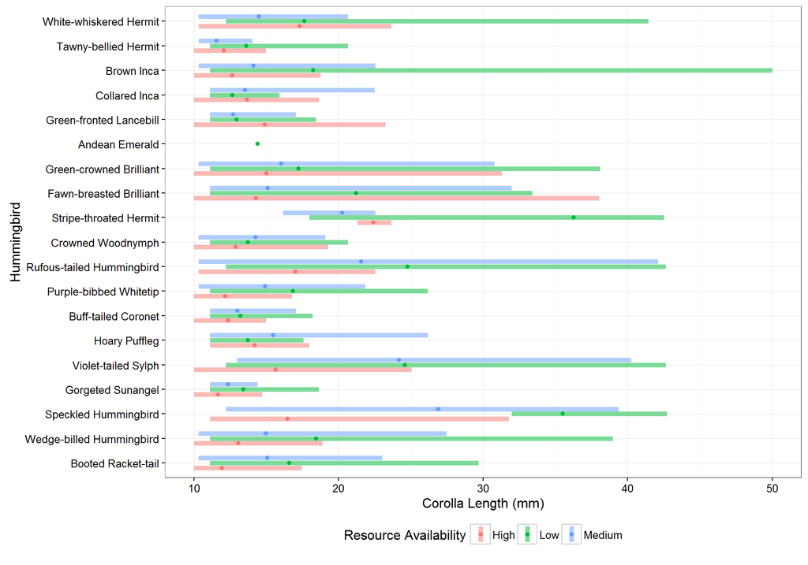

```r
meanstat<-nstat %>% filter(P==1) %>% group_by(Hummingbird,L1,Iteration) %>% summarize(a=min(Corolla))%>% summarize(mean=mean(a),lower=quantile(a,0.05),upper=quantile(a,0.95))

ggplot(meanstat,aes(x=Hummingbird,ymin=lower,ymax=upper,ymean=mean,col=L1)) + geom_linerange(alpha=0.5,position=position_dodge(width=.6),size=2) + geom_point(aes(y=mean),position=position_dodge(width=.6)) + labs(col="Resource Availability",y="Corolla Length (mm)") + theme_bw() + coord_flip() + theme(legend.position="bottom")
```

# Generate network

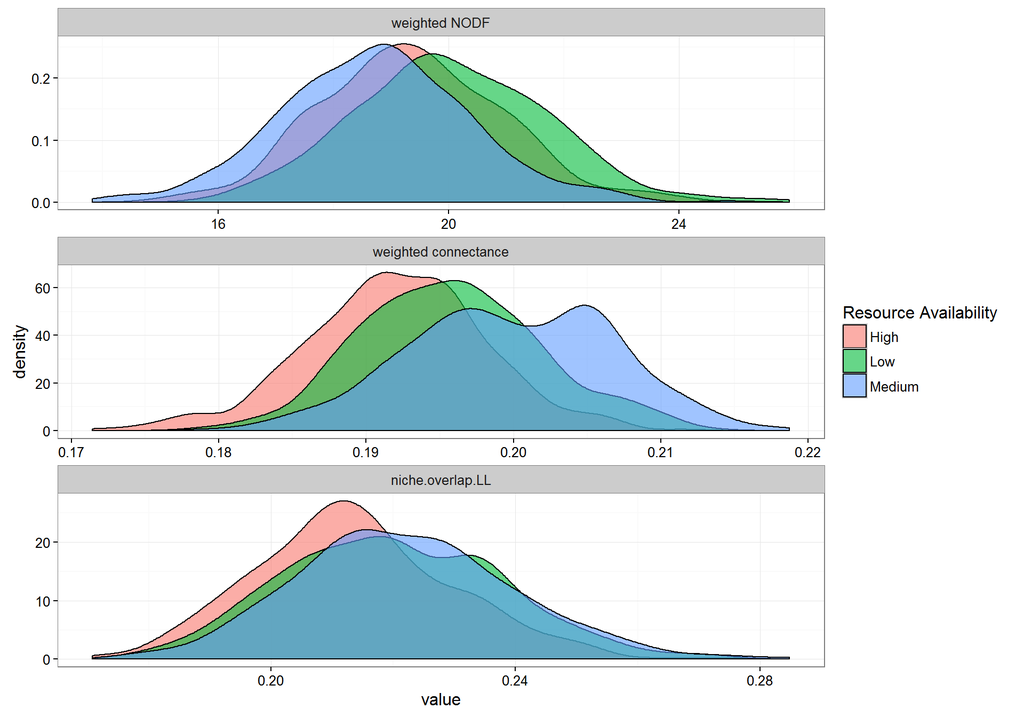

```r
#Split by resource
nsplit<-split(species.mean,species.mean$r)

makeN<-function(x){

  #input matrix
  aggm<-matrix(nrow=nrow(jagsIndexBird),ncol=nrow(jagsIndexPlants),data=0)
  for (j in 1:nrow(x)){
    aggm[x[j,"jBird"],x[j,"jPlant"]]<-rpois(1,lambda=x[j,"phi"])
  }
  #calculate network statistic
  nstat<-networklevel(aggm,index=c("weighted connectance","weighted NODF","niche overlap"),level="lower")
}

nstat<-lapply(nsplit,function(x){
  netstat<-melt(t(sapply(1:500,function(k) makeN(x))))
  colnames(netstat)<-c("Iteration","Metric","value")
  return(netstat)
})

names(nstat)<-c("Low","Medium","High")
nstat<-melt(nstat,colnames(nstat[[1]]))

ggplot(nstat,aes(x=value,fill=L1)) + geom_density(alpha=0.6) + facet_wrap(~Metric,scales='free',nrow=3) + scale_fill_discrete("Resource Availability") + theme_bw()
```

```r
ggsave("Figures/NetworkStatistics.jpeg",height=5,width=6,dpi=600)
```

Compared to raw visits

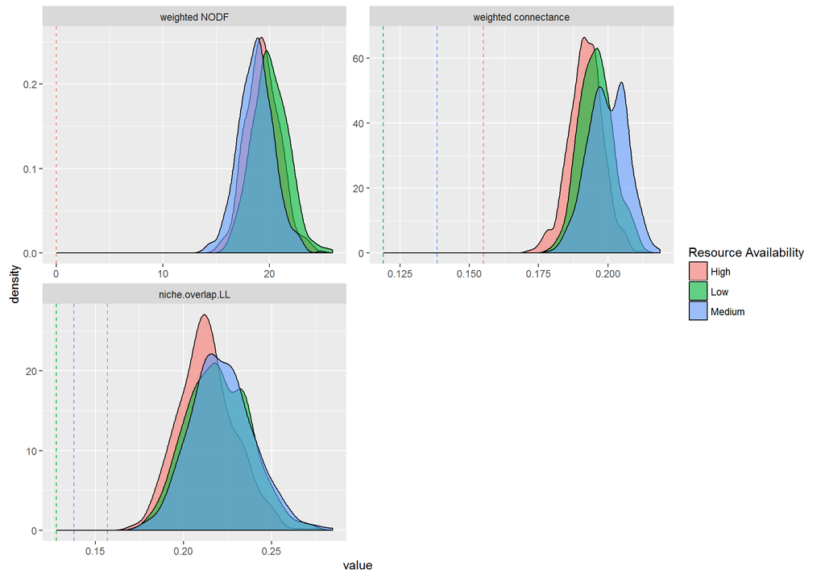

```r
sindat<-split(indat,indat$scaledR)
ndat<-lapply(sindat,function(x){
  web<-acast(x[x$Yobs==1,],Hummingbird~Iplant_Double,value.var = "Yobs", fun= function(x){ length(unique(x))})
  nstat<-t(networklevel(web,index=c("weighted connectance","weighted NODF","niche overlap"),level="lower"))
})
names(ndat)<-c("Low","Medium","High")
ndat<-melt(ndat)

colnames(ndat)<-c("Var1","Metric","value","L1")

ggplot(nstat,aes(x=value,fill=L1)) + geom_density(alpha=0.6) + facet_wrap(~Metric,scales='free',nrow=2) + scale_fill_discrete("Resource Availability") + geom_vline(data=ndat,aes(xintercept=value,col=L1),linetype="dashed") + scale_color_discrete(guide='none')
```

```r
save.image("ObservedModel.RData")
```